# ML_Assignment

Aloke Mascarenhas

October 7, 2016

## Activity Recognition

#### Practical Machine Learning Assignment - Sept / Oct 2016

## Synopsis :

The aim of this study is to accurately be able to quanitfy correctness of an activity. The used in this study is from the UCI-HAR library and is focused on dumbell lifts. [link](http://groupware.les.inf.puc-rio.br/har)

We will do the following in this study :

1. Brief EDA of the data to understand what the structure is like
2. Clean the data
3. Train ML classifiers and select the best ones based metrics
4. Predict activities based on the data in the testing set.

*Note : Summary and EDA outputs have been set to eval=FALSE to reduce verbose output, please select eval=TRUE to view the output*

## Initialize & EDA

Initialize libraries used in analysis

```r
library(caret)
library(AppliedPredictiveModeling)
library(dplyr)
```

Read in data and set seed

```r
setwd("C:/Documents/Coursera/CS_8_ML_NST/Assignment")
data_0<-read.csv("pml-training.csv")
testing_0<-read.csv("pml-testing.csv")
```

EDA on the data

```r
head(data_0)
str(data_0)
summary(data_0)
```

From the inital look at the data we can see that :

1. The first few columns (1:7) have username, timestamp and window with might not be useful to the learning algorithms. These can be omitted
2. The data has many NA values which offer us 2 choices in processing the data
   1. Omit the NA values before using the training algorithm.
   2. Omit them with the preProcess command from caret.

## Data Cleaning

```r
data_1<-data_0[,-c(1:7)]
naMean <- function(x){
  mean(is.na(x))
}
data_1_naMeans<-apply(data_1,2,naMean)
table(data_1_naMeans)
```

```
## data_1_naMeans
##                 0 0.979308938946081
##                86                67
```

From the table we can see that 67 columns have 98% NA values.

To facilitate preprocessing the data set efficiently we create a function:

```r
naClean <- function(dataFrame,threshold=0.9){
dataFrame_naMeans<-apply(dataFrame,2,naMean)
return(data_out <-dataFrame[,dataFrame_naMeans<threshold])
}
data_2<- naClean(data_1)
```

We take a look at the data to understand if more preprocessing is required

```r
str(data_2)
```

Studying the data we can see that there exists a few columns that have some concerning values

```r
str(data_2$kurtosis_yaw_belt)
```

```
##  Factor w/ 2 levels "","#DIV/0!": 1 1 1 1 1 1 1 1 1 1 ...
```

```r
table(data_2$kurtosis_yaw_belt)
```

```
##
##         #DIV/0!
##   19216     406
```

```r
str(data_2$amplitude_yaw_dumbbell)
```

```
##  Factor w/ 3 levels "","#DIV/0!","0.00": 1 1 1 1 1 1 1 1 1 1 ...
```

```r
table(data_2$amplitude_yaw_dumbbell)
```

```
##
##         #DIV/0!    0.00
##   19216       5     401
```

```r
str(data_2$amplitude_yaw_belt)
```

```
##  Factor w/ 4 levels "","#DIV/0!","0.00",..: 1 1 1 1 1 1 1 1 1 1 ...
```

```r
table(data_2$amplitude_yaw_belt)
```

```
##
##         #DIV/0!    0.00  0.0000
##   19216      10      12     384
```

```r
str(data_2$skewness_pitch_forearm)
```

```
##  Factor w/ 319 levels "","-0.0113","-0.0131",..: 1 1 1 1 1 1 1 1 1 1 ...
```

```r
table(data_2$skewness_pitch_forearm)
```

[output not shown]

[output cut: 18 more lines]

[output not shown]

```r
str(data_2$min_yaw_dumbbell)
```

```
##  Factor w/ 73 levels "","-0.1","-0.2",..: 1 1 1 1 1 1 1 1 1 1 ...
```

```r
table(data_2$min_yaw_dumbbell)
```

```
##
##            -0.1    -0.2    -0.3    -0.4    -0.5    -0.6    -0.7    -0.8
##   19216      12      15      16      14      14      20      13      18
##    -0.9    -1.0    -1.1    -1.2    -1.3    -1.4    -1.5    -1.6    -1.7
##      10      12      13       6       5       1       5       4       2
##    -1.8    -1.9    -2.0    -2.1    -2.2 #DIV/0!     0.0     0.1     0.2
##       1       3       1      11       1       5      15      13      19
##     0.3     0.4     0.5     0.6     0.7     0.8     0.9     1.0     1.1
##       8      11       7       9       5       8      11       4       9
##     1.2     1.3     1.4     1.5     1.6     1.7     1.8     1.9     2.0
##      10      11       4       4       4       2       2       1       3
##     2.1     2.2     2.4     2.5     2.6     2.7     2.8     2.9     3.0
##       3       3       1       1       2       2       1       1       1
##     3.2     3.3     3.4     3.5     3.7     4.0     4.2     4.4     5.1
##       1       2       1       4       5       1       1       1       2
##     5.2     5.3    55.0     6.0     6.1     6.2     7.4     7.6     8.0
##       2       1       1       1       1       1       1       1       1
##     8.9
##       1
```

From this it is evident that the data has the following :

1. Columns that are mostly NA values ~ 98%
2. Columns that have very low data content “” = 19216 + DIV/0! = 85 / 19622 (total data length)~ 98%

We thus append our data preprocessing function to include these columns

```r
naMean_2 <- function(x){
  mean(x==""|is.na(x))
}
naClean_2 <- function(dataFrame,threshold=0.9){
dataFrame_naMeans<-apply(dataFrame,2,naMean_2)
return(data_out <-dataFrame[,dataFrame_naMeans<threshold])
}
training_1 <- naClean_2(data_1)
```

## Training and selecting the optimal classifier

The resulting data is free from missing information and ready to process. We create a partition to allow for some data to be part of a Validation data set

```r
str(training_1)
```

```
## 'data.frame':    19622 obs. of  53 variables:
##  $ roll_belt           : num  1.41 1.41 1.42 1.48 1.48 1.45 1.42 1.42 1.43 1.45 ...
##  $ pitch_belt          : num  8.07 8.07 8.07 8.05 8.07 8.06 8.09 8.13 8.16 8.17 ...
##  $ yaw_belt            : num  -94.4 -94.4 -94.4 -94.4 -94.4 -94.4 -94.4 -94.4 -94.4 -94.4 ...
##  $ total_accel_belt    : int  3 3 3 3 3 3 3 3 3 3 ...
##  $ gyros_belt_x        : num  0 0.02 0 0.02 0.02 0.02 0.02 0.02 0.02 0.03 ...
##  $ gyros_belt_y        : num  0 0 0 0 0.02 0 0 0 0 0 ...
##  $ gyros_belt_z        : num  -0.02 -0.02 -0.02 -0.03 -0.02 -0.02 -0.02 -0.02 -0.02 0 ...
##  $ accel_belt_x        : int  -21 -22 -20 -22 -21 -21 -22 -22 -20 -21 ...
##  $ accel_belt_y        : int  4 4 5 3 2 4 3 4 2 4 ...
##  $ accel_belt_z        : int  22 22 23 21 24 21 21 21 24 22 ...
##  $ magnet_belt_x       : int  -3 -7 -2 -6 -6 0 -4 -2 1 -3 ...
##  $ magnet_belt_y       : int  599 608 600 604 600 603 599 603 602 609 ...
##  $ magnet_belt_z       : int  -313 -311 -305 -310 -302 -312 -311 -313 -312 -308 ...
##  $ roll_arm            : num  -128 -128 -128 -128 -128 -128 -128 -128 -128 -128 ...
```

[output cut: 39 more lines]

```r
inTrain <- createDataPartition(training_1$classe,p=0.70,list = FALSE)
training <- training_1[inTrain,]
validation <- training_1[-inTrain,]
```

Important part of this computation is parallel processing, the function used is defined here. It outputs model run time that allows for us to make model selection decisions later on.

```r
# Parallel processing function,to help reduce runtime
runparproc<-function(model.fun=x()){
  require(parallel)
  require(doParallel)
  # convention to leave 1 core for OS
  cluster <- makeCluster(detectCores() - 1)
  registerDoParallel(cluster)
  ptm <- proc.time()
  model.fun
  elap <- proc.time() - ptm
  stopCluster(cluster)
  print(elap)
}
```

To understand which model gives us the best measure of performance, we run 6 models with default training values and study the results. For this we use k-fold cross validation.

We select the following models : GBM,SVM,RPART,RF,LDA,KNN

In order save time, we run each model in a parallel processing function, detailed above and log the time to train ech model

```r
control_0 <- trainControl(method="repeatedcv",
                        number=10,repeats=3)
set.seed(7)
# train the GBM model
time_matrix <- rbind(time_gbm <- runparproc(modelGbm_0 <- train(classe~.,data=training,
                  method="gbm", trControl=control_0,
                  verbose=FALSE,metric="Accuracy")),
# train the SVM model
time_svm <- runparproc(modelSvm_0 <- train(classe~.,data=training,
                  method="svmRadial", trControl=control_0,
                  metric="Accuracy")),
# train the rpart model
time_rpart <- runparproc(modelrpart_0 <- train(classe~.,data=training,
                  method="rpart", trControl=control_0,
                  metric="Accuracy")),
# train the randomforest model
time_rf <- runparproc(modelrf_0 <- train(classe~.,data=training,
                  method="rf", trControl=control_0,
                  metric="Accuracy")),
# train the LDA model
time_lda <- runparproc(modelLda_0 <- train(classe~.,data=training,
                  method="lda", trControl=control_0,
                  metric="Accuracy")),
# train the KNN model
time_knn <- runparproc(modelknn_0 <- train(classe~.,data=training,
                  method="knn", trControl=control_0,
                  metric="Accuracy")))
```

```
##    user  system elapsed
##   34.95    0.44  927.29
```

```
##    user  system elapsed
##   32.22    2.03 1891.61
```

```
##    user  system elapsed
##    4.66    0.09   16.05
```

```
##    user  system elapsed
##   50.81    0.36 2442.55
```

```
##    user  system elapsed
##    0.91    0.17   12.27
##    user  system elapsed
##    0.76    0.09  140.84
```

```r
# collect resamples
results_0 <- resamples(list(GBM=modelGbm_0,SVM=modelSvm_0,
                            RP=modelrpart_0,RF=modelrf_0,
                            LDA=modelLda_0,KNN = modelknn_0))
#store summary
res0Summary <- summary(results_0)
eval_matrix <- cbind(as.data.frame(res0Summary$models),
                    (as.data.frame(res0Summary$statistics$Accuracy)$Mean),
                    (as.data.frame(res0Summary$statistics$Kappa)$Mean),
                    time_matrix[,3])

names(eval_matrix) <- c("Models","Accuracy","Kappa","runTimes")
eval_matrix<-mutate(eval_matrix,timePerAccuracy= runTimes/(Accuracy*100))
```

Summarizing the results from the model evaluation

```r
# summarize the distributions results 0
summary(results_0)
```

```
##
## Call:
## summary.resamples(object = results_0)
##
## Models: GBM, SVM, RP, RF, LDA, KNN
## Number of resamples: 30
##
## Accuracy
##       Min. 1st Qu. Median   Mean 3rd Qu.   Max. NA's
## GBM 0.9520  0.9565 0.9603 0.9602  0.9641 0.9687    0
## SVM 0.9068  0.9210 0.9264 0.9248  0.9284 0.9367    0
## RP  0.4669  0.4954 0.5031 0.5172  0.5252 0.5869    0
## RF  0.9883  0.9907 0.9920 0.9925  0.9949 0.9978    0
## LDA 0.6783  0.6903 0.6975 0.6998  0.7061 0.7300    0
## KNN 0.8791  0.8931 0.8999 0.8992  0.9046 0.9150    0
##
## Kappa
##       Min. 1st Qu. Median   Mean 3rd Qu.   Max. NA's
## GBM 0.9392  0.9450 0.9498 0.9497  0.9546 0.9604    0
## SVM 0.8819  0.8999 0.9068 0.9047  0.9093 0.9198    0
## RP  0.3031  0.3405 0.3517 0.3746  0.3900 0.4779    0
## RF  0.9853  0.9883 0.9899 0.9905  0.9936 0.9972    0
## LDA 0.5938  0.6078 0.6170 0.6202  0.6286 0.6587    0
## KNN 0.8471  0.8648 0.8733 0.8725  0.8792 0.8924    0
```

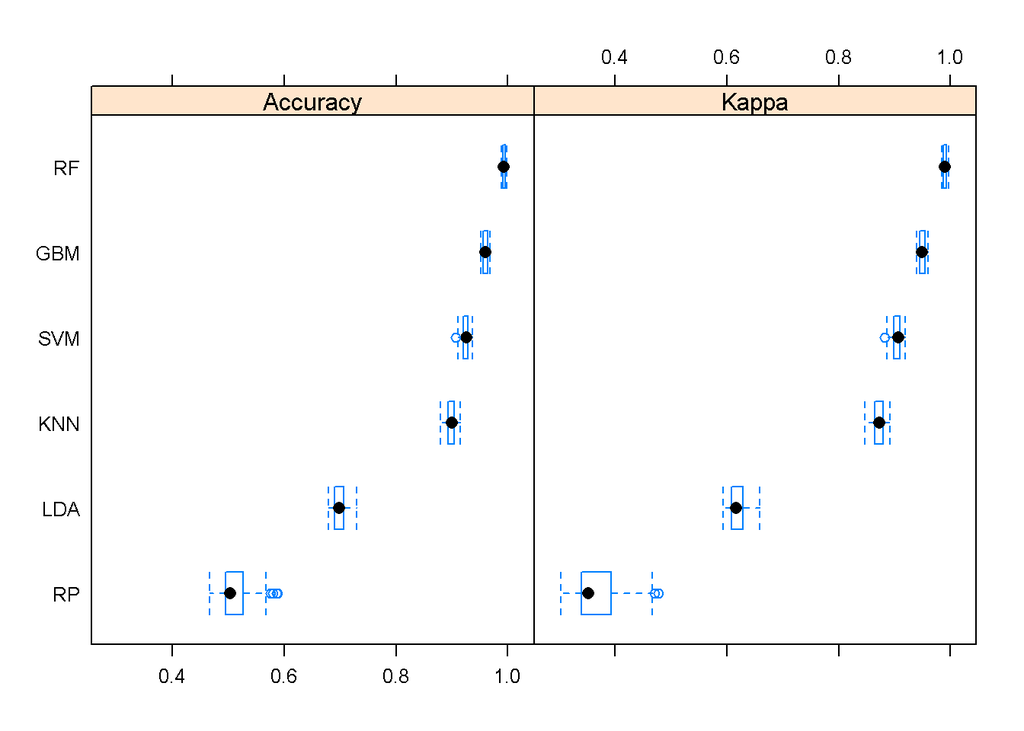

```r
# boxplots of results 0
bwplot(results_0)
```

```r
# model selection matrix - results 0
eval_matrix
```

```
##   Models Accuracy  Kappa runTimes timePerAccuracy
## 1    GBM   0.9602 0.9497   927.29       9.6572589
## 2    SVM   0.9248 0.9047  1891.61      20.4542604
## 3     RP   0.5172 0.3746    16.05       0.3103248
## 4     RF   0.9925 0.9905  2442.55      24.6100756
## 5    LDA   0.6998 0.6202    12.27       0.1753358
## 6    KNN   0.8992 0.8725   140.84       1.5662811
```

From the matrix we can select the models for future evaluation in 2 steps.

1. Selecting methods with Kappa above 80%
2. Selecting the models with the best “Time per accuracy” - % accuracy obtained for train time

**Using this logic, we fine tune our models to just the KNN & GBM**

The next step is to grid tuning the selected models to find the most optimal model for our application

We run the following cases *(See Appendix for model results)*:

1. GBM Model with pca accounting for 95% of variance obtained
2. GBM Model with no pca and grid tune length = 5
3. KNN Model with pca , tune length = 10
4. KNN Model with centering and scaling the data , tune length = 10

```r
control_1 <- trainControl(method="repeatedcv",
                        number=10,repeats=3,
                        preProcOptions = list(thresh=0.95))

# train the GBM model - Only pca
time_matrix_1 <- rbind(runparproc(modelGbm_1 <- train(classe~.,data=training,
                  method="gbm", trControl=control_1,
                  verbose=FALSE,metric="Accuracy",preProcess="pca")),
# train the GBM model - length =5
runparproc(modelGbm_2 <- train(classe~.,data=training,
                  method="gbm", trControl=control_1,
                  verbose=FALSE,metric="Accuracy",tuneLength=5)),
# train the KNN model - pca , length 10
runparproc(modelknn_1 <- train(classe~.,data=training,
                  method="knn", trControl=control_1,
                  metric="Accuracy",preProcess="pca",tuneLength=10)),
# train the KNN model - center, scale, length 10
runparproc(modelknn_2 <- train(classe~.,data=training,
                  method="knn", trControl=control_1,
                  metric="Accuracy",preProcess=c("center","scale"),tuneLength=10)))
```

```
##    user  system elapsed
##   18.98    0.71  643.40
##    user  system elapsed
##   73.80    1.07 3219.39
##    user  system elapsed
##    1.80    0.18  220.45
##    user  system elapsed
##    1.05    0.06  489.59
```

```r
# collect resamples
results_1 <- resamples(list(GBM_1= modelGbm_1,GBM_2= modelGbm_2,
                            KNN_1= modelknn_1,KNN_2= modelknn_2))
# summarize the distributions results 1
res1Summary<-summary(results_1)

eval_matrix_1 <- cbind(as.data.frame(res1Summary$models),
                    (as.data.frame(res1Summary$statistics$Accuracy)$Mean),
                    (as.data.frame(res1Summary$statistics$Kappa)$Mean),
                    time_matrix_1[,3])

names(eval_matrix_1) <- c("Models","Accuracy","Kappa","runTimes")
eval_matrix_1<-mutate(eval_matrix_1,timePerAccuracy= runTimes/(Accuracy*100))

# summary of results 1
res1Summary
```

```
##
## Call:
## summary.resamples(object = results_1)
##
## Models: GBM_1, GBM_2, KNN_1, KNN_2
## Number of resamples: 30
##
## Accuracy
##         Min. 1st Qu. Median   Mean 3rd Qu.   Max. NA's
## GBM_1 0.8026  0.8165 0.8230 0.8220  0.8278 0.8486    0
## GBM_2 0.9847  0.9873 0.9894 0.9894  0.9911 0.9956    0
## KNN_1 0.9403  0.9500 0.9527 0.9527  0.9548 0.9621    0
## KNN_2 0.9519  0.9585 0.9607 0.9613  0.9629 0.9760    0
##
## Kappa
##         Min. 1st Qu. Median   Mean 3rd Qu.   Max. NA's
## GBM_1 0.7501  0.7676 0.7760 0.7745  0.7818 0.8087    0
## GBM_2 0.9806  0.9839 0.9866 0.9866  0.9887 0.9945    0
## KNN_1 0.9246  0.9368 0.9401 0.9402  0.9429 0.9520    0
## KNN_2 0.9392  0.9475 0.9502 0.9511  0.9531 0.9696    0
```

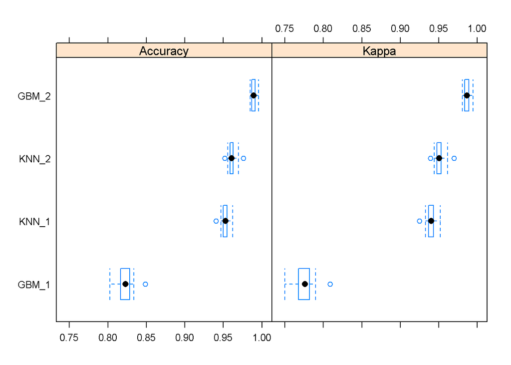

```r
# boxplots of results 1
bwplot(results_1)
```

```r
# model selection matrix - results 1
eval_matrix_1
```

```
##   Models Accuracy  Kappa runTimes timePerAccuracy
## 1  GBM_1   0.8220 0.7745   643.40        7.827251
## 2  GBM_2   0.9894 0.9866  3219.39       32.538811
## 3  KNN_1   0.9527 0.9402   220.45        2.313950
## 4  KNN_2   0.9613 0.9511   489.59        5.092999
```

## Validation and Prediction

```r
knn_validation<-confusionMatrix(validation$classe,predict(modelknn_2,validation))
knn_validation$overall[c(1,2)]
```

```
##  Accuracy     Kappa
## 0.9677145 0.9591503
```

We can now proceeed to prediction with the test data set after preprocessing the data same as the training set

```r
testing_1<-testing_0[,-c(1:7)]
testing <- naClean_2(testing_1)
predictions <- predict(modelknn_2,testing)
predictions
```

```
##  [1] B A B A A E D B A A B C B A E E A B B B
## Levels: A B C D E
```

These are the predicted values for the testing set and will be used in the quiz to verify accuracy.

## Appendix

```r
# train the GBM model - Only pca
modelGbm_1
```

```
## Stochastic Gradient Boosting
##
## 13737 samples
##    52 predictor
##     5 classes: 'A', 'B', 'C', 'D', 'E'
##
## Pre-processing: principal component signal extraction (52), centered
##  (52), scaled (52)
## Resampling: Cross-Validated (10 fold, repeated 3 times)
## Summary of sample sizes: 12363, 12364, 12362, 12363, 12363, 12363, ...
## Resampling results across tuning parameters:
##
##   interaction.depth  n.trees  Accuracy   Kappa
##   1                   50      0.5585136  0.4338807
##   1                  100      0.6207324  0.5170702
##   1                  150      0.6502388  0.5555377
##   2                   50      0.6542659  0.5607121
##   2                  100      0.7284943  0.6560153
##   2                  150      0.7679004  0.7060206
##   3                   50      0.7160704  0.6400744
##   3                  100      0.7860995  0.7290840
##   3                  150      0.8219638  0.7745387
##
## Tuning parameter 'shrinkage' was held constant at a value of 0.1
##
## Tuning parameter 'n.minobsinnode' was held constant at a value of 10
## Accuracy was used to select the optimal model using  the largest value.
## The final values used for the model were n.trees = 150,
##  interaction.depth = 3, shrinkage = 0.1 and n.minobsinnode = 10.
```

```r
# train the GBM model - length =5
modelGbm_2
```

```
## Stochastic Gradient Boosting
##
## 13737 samples
##    52 predictor
##     5 classes: 'A', 'B', 'C', 'D', 'E'
##
## No pre-processing
## Resampling: Cross-Validated (10 fold, repeated 3 times)
## Summary of sample sizes: 12363, 12363, 12363, 12364, 12364, 12366, ...
## Resampling results across tuning parameters:
##
##   interaction.depth  n.trees  Accuracy   Kappa
##   1                   50      0.7585348  0.6940121
##   1                  100      0.8226205  0.7755135
##   1                  150      0.8541646  0.8154647
##   1                  200      0.8741354  0.8406999
##   1                  250      0.8876757  0.8578182
##   2                   50      0.8558400  0.8173664
##   2                  100      0.9065543  0.8817604
##   2                  150      0.9327614  0.9149159
##   2                  200      0.9462769  0.9320256
##   2                  250      0.9560072  0.9443444
##   3                   50      0.8954402  0.8676328
##   3                  100      0.9423944  0.9271099
##   3                  150      0.9606415  0.9502082
##   3                  200      0.9706630  0.9628891
##   3                  250      0.9775059  0.9715464
##   4                   50      0.9214533  0.9005870
##   4                  100      0.9580215  0.9468901
##   4                  150      0.9725319  0.9652537
##   4                  200      0.9811464  0.9761514
##   4                  250      0.9857323  0.9819527
##   5                   50      0.9379528  0.9214743
##   5                  100      0.9679220  0.9594176
##   5                  150      0.9807334  0.9756297
##   5                  200      0.9861929  0.9825355
##   5                  250      0.9894201  0.9866178
##
## Tuning parameter 'shrinkage' was held constant at a value of 0.1
##
## Tuning parameter 'n.minobsinnode' was held constant at a value of 10
## Accuracy was used to select the optimal model using  the largest value.
## The final values used for the model were n.trees = 250,
##  interaction.depth = 5, shrinkage = 0.1 and n.minobsinnode = 10.
```

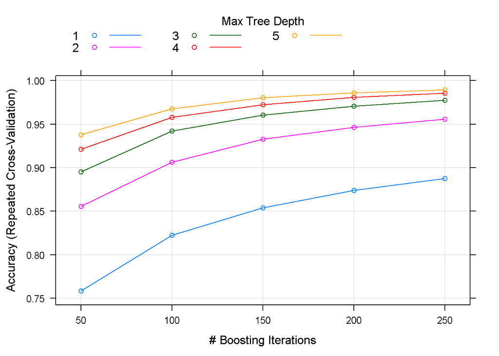

```r
plot(modelGbm_2)
```

```r
# train the KNN model - pca , length 10
modelknn_1
```

```
## k-Nearest Neighbors
##
## 13737 samples
##    52 predictor
##     5 classes: 'A', 'B', 'C', 'D', 'E'
##
## Pre-processing: principal component signal extraction (52), centered
##  (52), scaled (52)
## Resampling: Cross-Validated (10 fold, repeated 3 times)
## Summary of sample sizes: 12363, 12363, 12363, 12364, 12364, 12364, ...
## Resampling results across tuning parameters:
##
##   k   Accuracy   Kappa
##    5  0.9527086  0.9401669
##    7  0.9399938  0.9240744
##    9  0.9281512  0.9090808
##   11  0.9159942  0.8936999
##   13  0.9033520  0.8776919
##   15  0.8935254  0.8652642
##   17  0.8830917  0.8520629
##   19  0.8748901  0.8416819
##   21  0.8656446  0.8299971
##   23  0.8568117  0.8188359
##
## Accuracy was used to select the optimal model using  the largest value.
## The final value used for the model was k = 5.
```

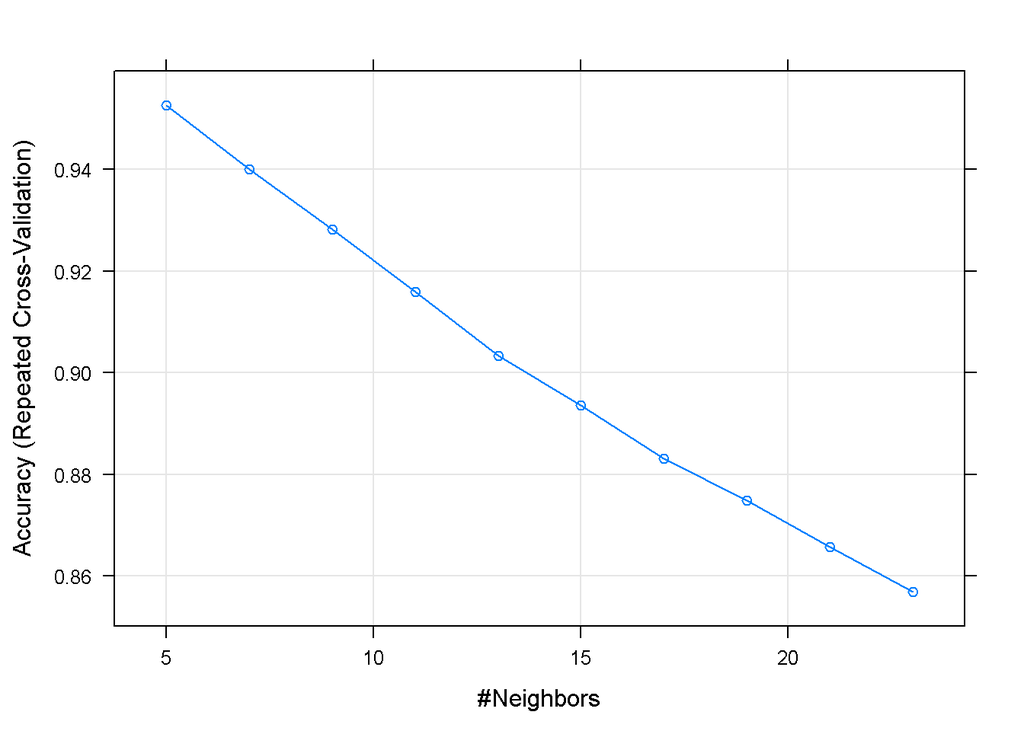

```r
plot(modelknn_1)
```

```r
# train the KNN model - center, scale, length 10
modelknn_2
```

```
## k-Nearest Neighbors
##
## 13737 samples
##    52 predictor
##     5 classes: 'A', 'B', 'C', 'D', 'E'
##
## Pre-processing: centered (52), scaled (52)
## Resampling: Cross-Validated (10 fold, repeated 3 times)
## Summary of sample sizes: 12364, 12364, 12363, 12362, 12365, 12363, ...
## Resampling results across tuning parameters:
##
##   k   Accuracy   Kappa
##    5  0.9613453  0.9510961
##    7  0.9483384  0.9346332
##    9  0.9363752  0.9194843
##   11  0.9251402  0.9052633
##   13  0.9126438  0.8894454
##   15  0.9030106  0.8772470
##   17  0.8936681  0.8654274
##   19  0.8842773  0.8535612
##   21  0.8769982  0.8443459
##   23  0.8703739  0.8359551
##
## Accuracy was used to select the optimal model using  the largest value.
## The final value used for the model was k = 5.
```

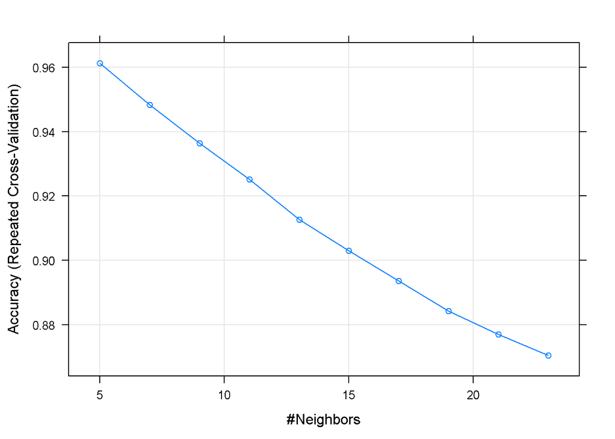

```r
plot(modelknn_2)
```